# Technoecom: Digital Transformation - Project 1

```
Title: Bivariate Numerical column - Scatterplot of order_price
```

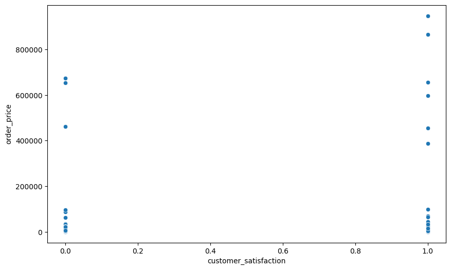

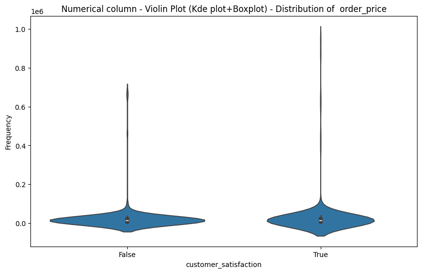

```
Bivariate analysis between customer_satisfaction and 'order_price':
order_price
(-947.691, 189538.2]    0.521385
(189538.2, 379076.4]         NaN
(379076.4, 568614.6]    0.666667
(568614.6, 758152.8]    0.500000
(758152.8, 947691.0]    1.000000
Name: customer_satisfaction, dtype: float64
Title: Bivariate Numerical column - Scatterplot of delivery_charges
```

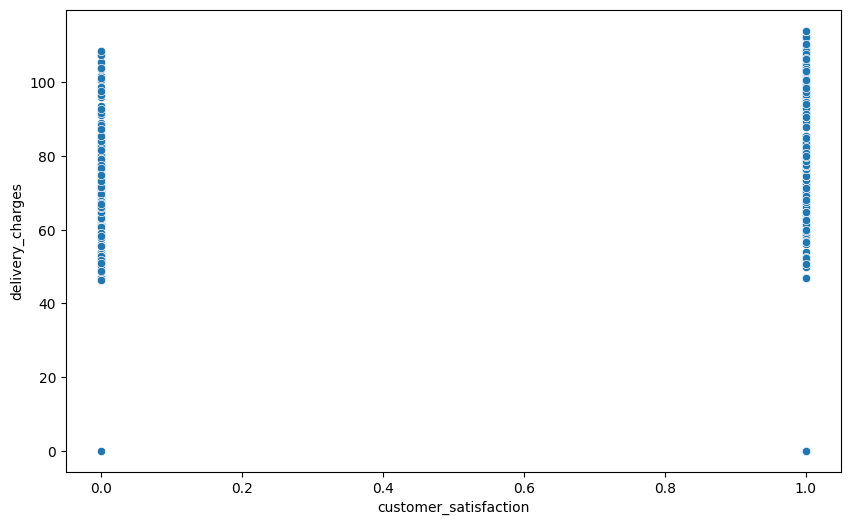

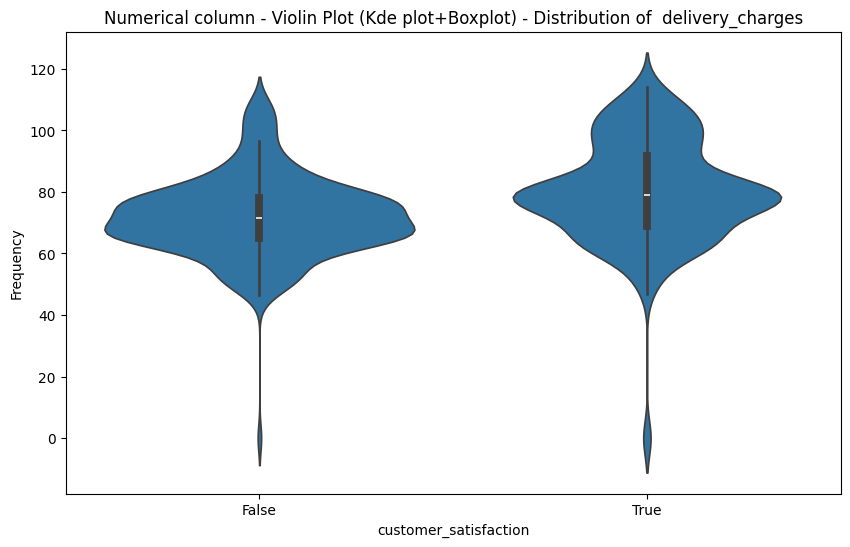

```
Bivariate analysis between customer_satisfaction and 'delivery_charges':
delivery_charges
(-0.114, 22.808]    0.750000
(22.808, 45.616]         NaN
(45.616, 68.424]    0.373494
(68.424, 91.232]    0.526749
(91.232, 114.04]    0.793103
Name: customer_satisfaction, dtype: float64
Title: Bivariate Numerical column - Scatterplot of coupon_discount
```

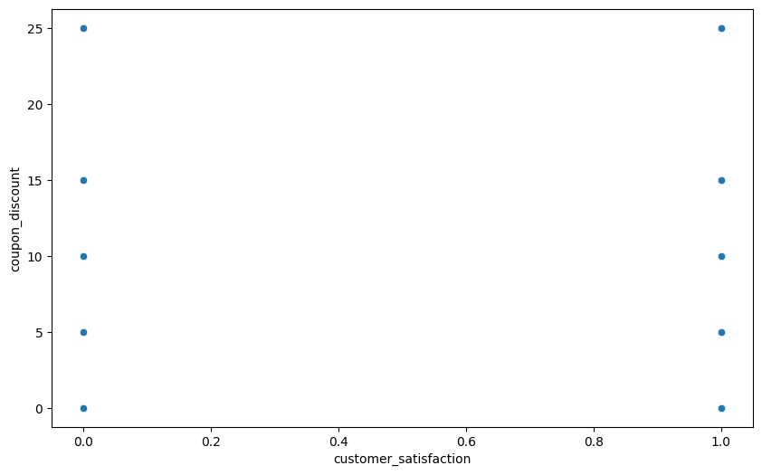

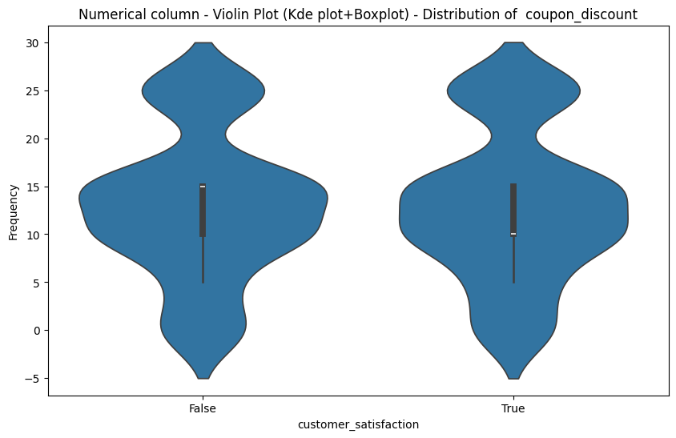

```
Bivariate analysis between customer_satisfaction and 'coupon_discount':
coupon_discount
(-0.025, 5.0]    0.548077
(5.0, 10.0]      0.524476
(10.0, 15.0]     0.493506
(15.0, 20.0]          NaN
(20.0, 25.0]     0.545455
Name: customer_satisfaction, dtype: float64
Title: Bivariate Numerical column - Scatterplot of distance_to_nearest_warehouse
```

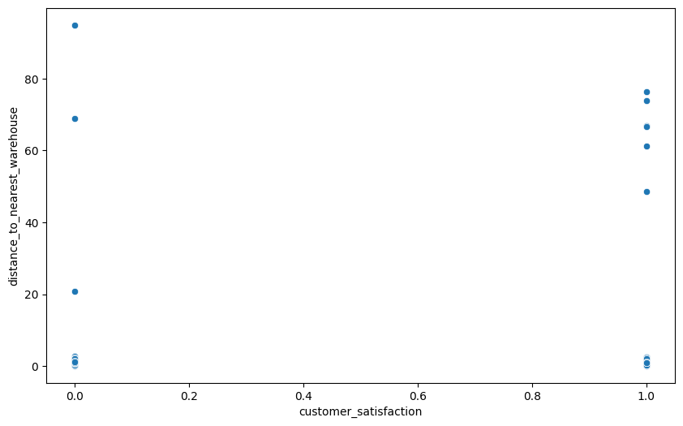

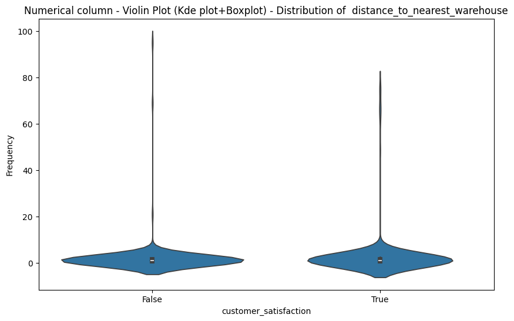

```
Bivariate analysis between customer_satisfaction and 'distance_to_nearest_warehouse':
distance_to_nearest_warehouse
(0.0129, 19.081]    0.521385
(19.081, 38.054]    0.000000
(38.054, 57.027]    1.000000
(57.027, 76.0]      0.800000
(76.0, 94.973]      0.500000
Name: customer_satisfaction, dtype: float64
Title: Bivariate Numerical column - Scatterplot of age
```

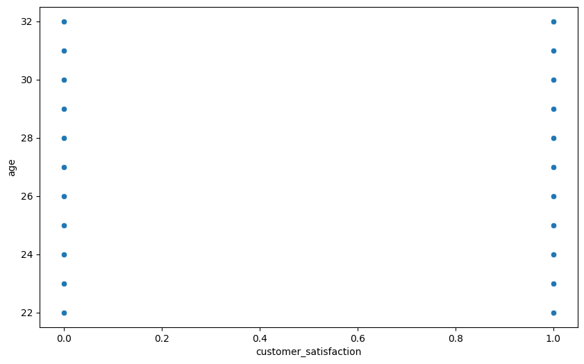

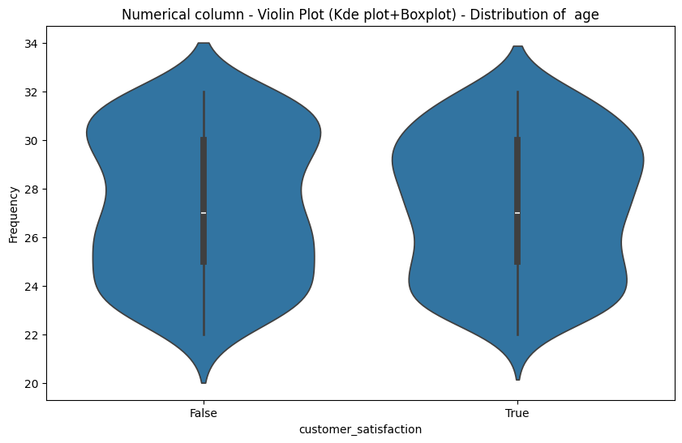

```
Bivariate analysis between customer_satisfaction and 'age':
age
(21.99, 24.0]    0.517544
(24.0, 26.0]     0.494737
(26.0, 28.0]     0.574468
(28.0, 30.0]     0.563636
(30.0, 32.0]     0.459770
Name: customer_satisfaction, dtype: float64
Title: Bivariate Numerical column - Scatterplot of total_bill
```

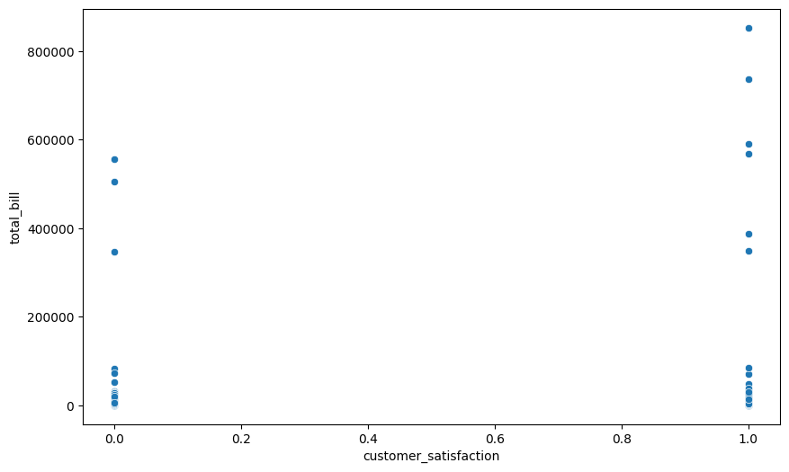

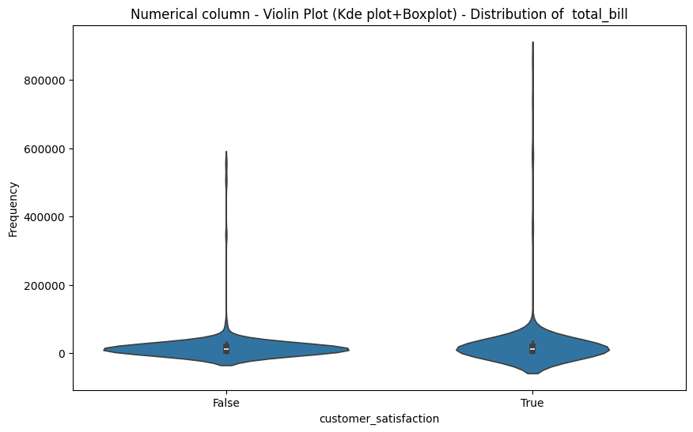

```
Bivariate analysis between customer_satisfaction and 'total_bill':
total_bill
(-784.704, 170657.136]      0.521385
(170657.136, 341246.032]         NaN
(341246.032, 511834.928]    0.500000
(511834.928, 682423.824]    0.666667
(682423.824, 853012.72]     1.000000
Name: customer_satisfaction, dtype: float64
```

```python
# Perform bivariate analysis for different Numerical columns
for column in numerical_vars_arrays:
    perform_bivariate_analysis(dataset,column)
```

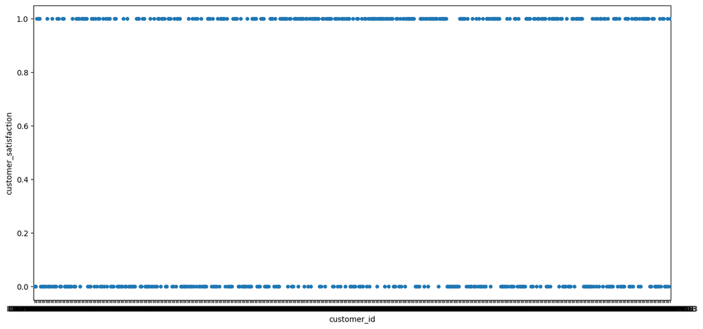

```
Bivariate analysis between customer_satisfaction and 'customer_id':
customer_id
ID0026051948    1.0
ID0030385486    0.0
ID0030385740    0.0
ID0030945778    1.0
ID0030946633    1.0
               ...
ID6226013492    0.0
ID6231506306    0.0
ID6231506320    1.0
ID6245731028    0.0
ID6282174092    1.0
Name: customer_satisfaction, Length: 500, dtype: float64
```

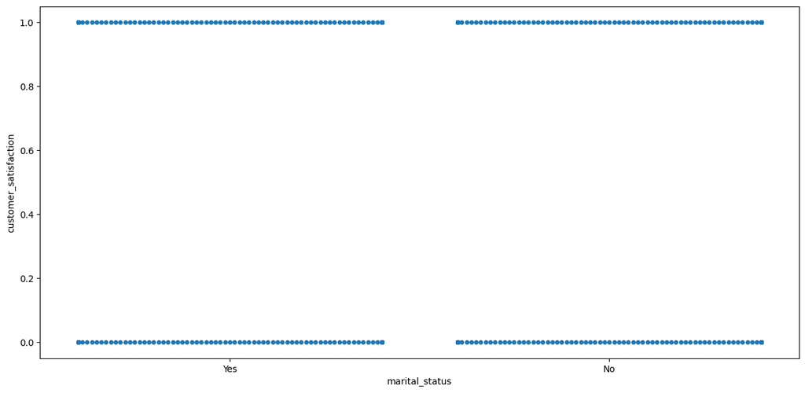

```
Bivariate analysis between customer_satisfaction and 'marital_status':
marital_status
No     0.500000
Yes    0.545113
Name: customer_satisfaction, dtype: float64
```

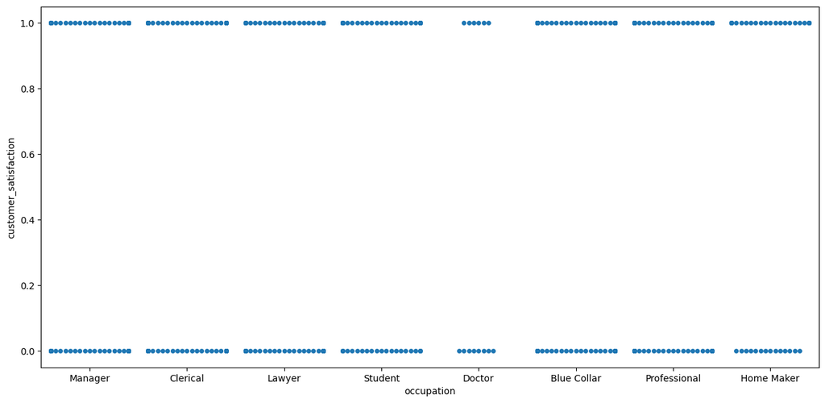

```
Bivariate analysis between customer_satisfaction and 'occupation':
occupation
Blue Collar     0.530000
Clerical        0.619048
Doctor          0.428571
Home Maker      0.621622
Lawyer          0.424242
Manager         0.479452
Professional    0.473684
Student         0.580000
Name: customer_satisfaction, dtype: float64
```

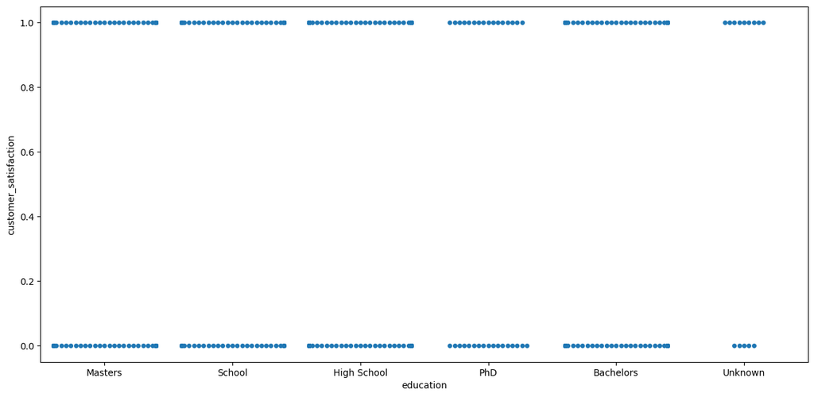

```
Bivariate analysis between customer_satisfaction and 'education':
education
Bachelors      0.507353
High School    0.565789
Masters        0.453608
PhD            0.484848
School         0.558824
Unknown        0.642857
Name: customer_satisfaction, dtype: float64
```

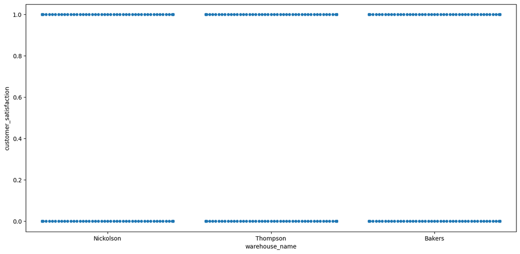

```
Bivariate analysis between customer_satisfaction and 'warehouse_name':
warehouse_name
Bakers       0.521008
Nickolson    0.538043
Thompson     0.512690
Name: customer_satisfaction, dtype: float64
```

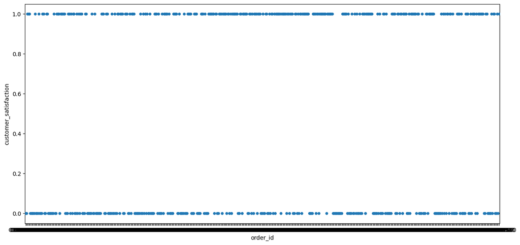

```
Bivariate analysis between customer_satisfaction and 'order_id':
order_id
ORD001041    0.0
ORD004361    0.0
ORD004602    1.0
ORD004848    1.0
ORD005232    1.0
            ...
ORD497096    0.0
ORD497160    0.0
ORD498207    1.0
ORD498590    0.0
ORD499540    1.0
Name: customer_satisfaction, Length: 500, dtype: float64
```

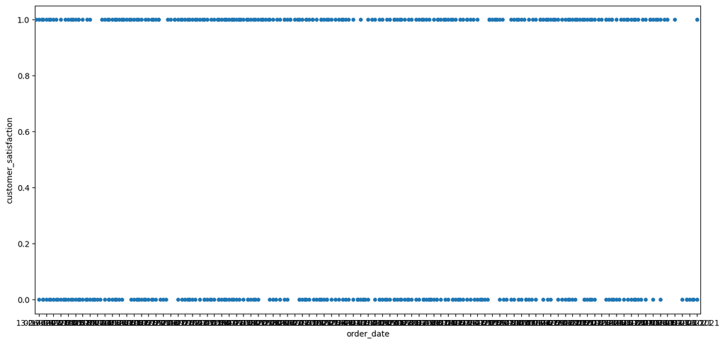

```
Bivariate analysis between customer_satisfaction and 'order_date':
order_date
01-05-2021    0.600000
01-06-2021    0.500000
01-07-2021    0.000000
02-05-2021    1.000000
02-06-2021    0.555556
                ...
29-07-2021    0.250000
30-05-2021    0.500000
30-06-2021    1.000000
30-07-2021    0.333333
31-05-2021    0.400000
Name: customer_satisfaction, Length: 91, dtype: float64
```

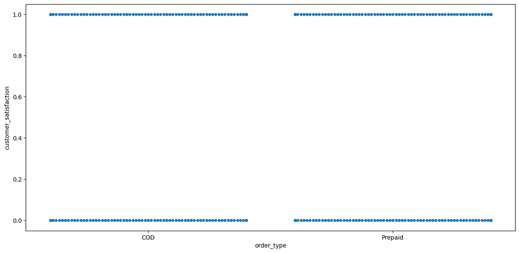

```
Bivariate analysis between customer_satisfaction and 'order_type':
order_type
COD        0.445055
Prepaid    0.569182
Name: customer_satisfaction, dtype: float64
```

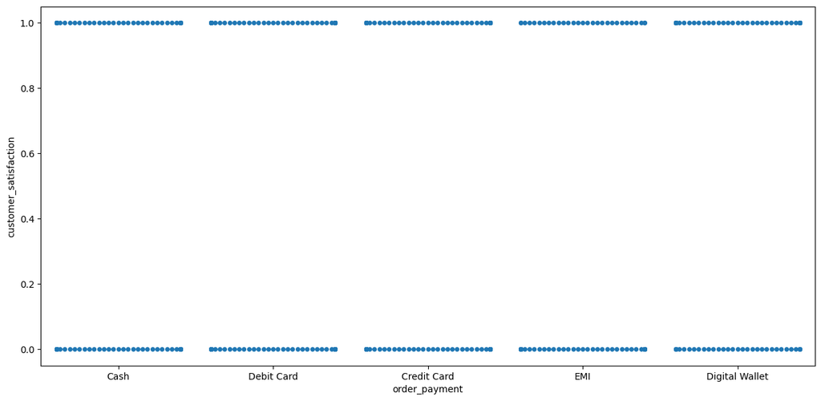

```
Bivariate analysis between customer_satisfaction and 'order_payment':
order_payment
Cash              0.338843
Credit Card       0.487805
Debit Card        0.511628
Digital Wallet    0.765957
EMI               0.414286
Name: customer_satisfaction, dtype: float64
```

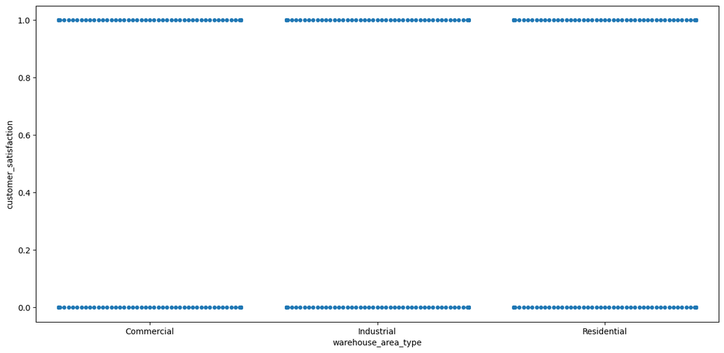

```
Bivariate analysis between customer_satisfaction and 'warehouse_area_type':
warehouse_area_type
Commercial     0.538043
Industrial     0.512690
Residential    0.521008
Name: customer_satisfaction, dtype: float64
```

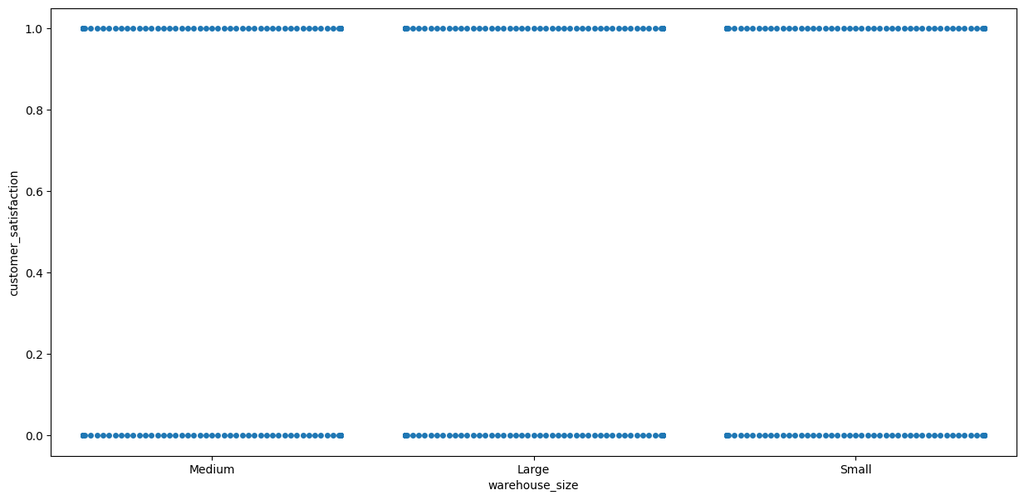

```
Bivariate analysis between customer_satisfaction and 'warehouse_size':
warehouse_size
Large     0.512690
Medium    0.538043
Small     0.521008
Name: customer_satisfaction, dtype: float64
```

```python
# Perform bivariate analysis for different Categorical columns
for column in categorical_vars_arrays:
    perform_bivariate_analysis(dataset,column)
```

## Observation

- As per the above graph, there is no relationship between order price and customer satisfaction.
- As per the above graph, customers are more satisfied with higher delivery charges.
- As per the above graph, there is no relationship between total bills and customer satisfaction.
- As per the above graph, there is no relationship between delivery_to_nearest_warehouse and customer satisfaction.

## Outlier Treatment

Identify the columns in the dataset with the help of plots that was displayed above are required to treat outliers

```python
def treat_outliers_iqr(df, column):

  #Calculate the first quartile (Q1) and third quartile (Q3)
  Q1 = df[column].quantile(0.25)
  Q3 = df[column].quantile(0.75)

  # Calculate the interquartile range (IQR)
  IQR = Q3 - Q1

  # Define the Lower and upper bounds for outliers
  lower_bound = Q1 - 1.5 * IQR
  upper_bound = Q3 + 1.5 * IQR

  # Identify outliers
  outliers = df[(df[column] < lower_bound) | (df[column] > upper_bound)]

  # Replace outliers with the mean value
  mean_value = df[column].mean()
  df.loc[(df[column] < lower_bound) | (df [column] > upper_bound), column] = mean_value

  return df, outliers
```

```python
df, outliers = treat_outliers_iqr(dataset, 'order_price')
```

```python
print(len(outliers))
```

```
16
```

```python
df, outliers = treat_outliers_iqr(dataset, 'total_bill')
```

```python
print(len(outliers))
```

```
16
```

```python
df, outliers = treat_outliers_iqr(dataset, 'distance_to_nearest_warehouse')
```

```python
print(len(outliers))
```

```
12
```

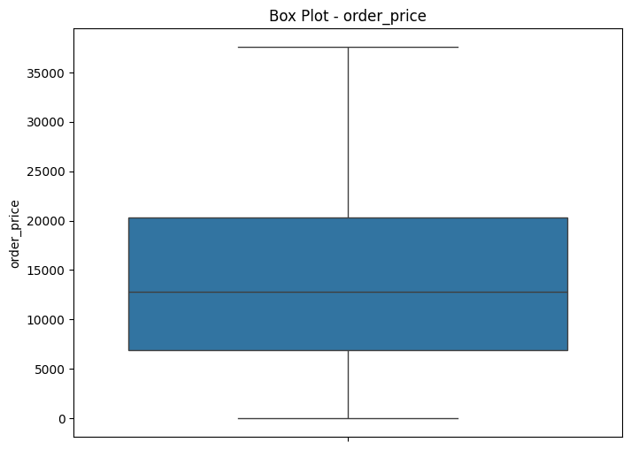

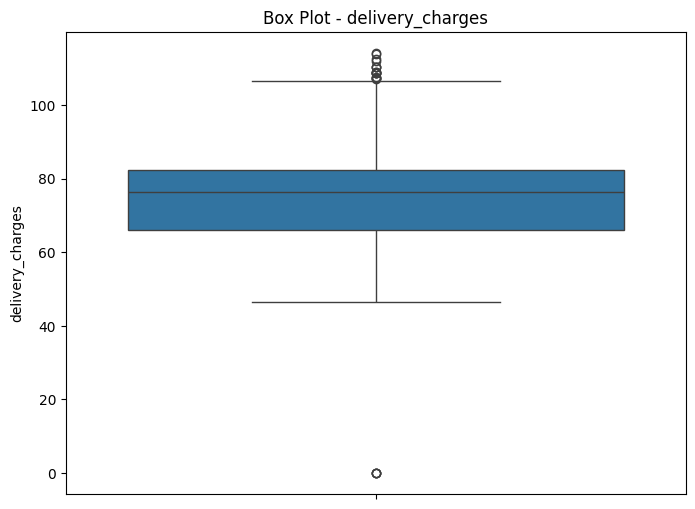

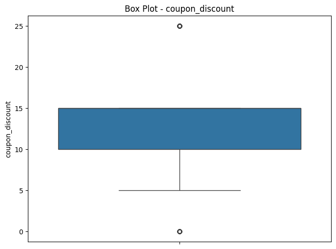

[figure not shown]

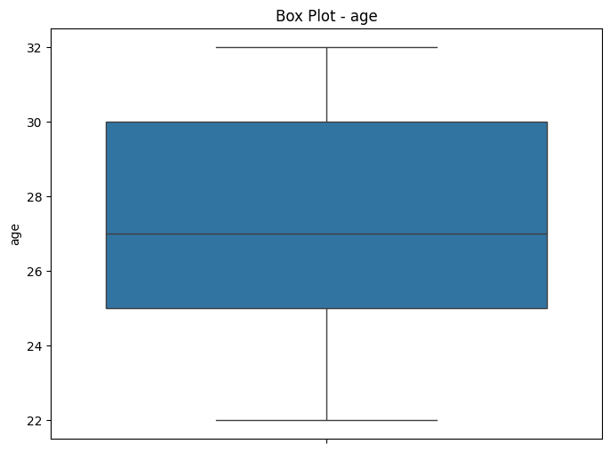

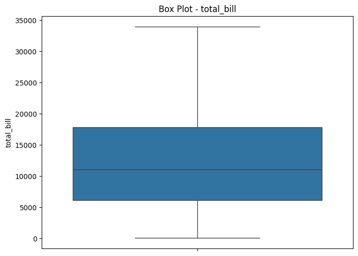

```python
# write you are code here# Create box plots for each numerical column
for column in numerical_vars_arrays:
    plt.figure(figsize=(8, 6))
    sns.boxplot(data=dataset, y=column)
    plt.title(f'Box Plot - {column}')
    plt.show()
```

## Answer the following business questions based upon the data

##### [Q1] What is the revenue across each warehouse?

```python
# write you are code here
# Group by warehouse_name and calculate the sum of total_bill for each warehouse
revenue_by_warehouse = dataset.groupby('warehouse_name')['total_bill'].sum()

# Print the revenue across each warehouse
print(revenue_by_warehouse)
```

```
warehouse_name
Bakers       1.469605e+06
Nickolson    2.152123e+06
Thompson     2.422910e+06
Name: total_bill, dtype: float64
```

##### [Q2] What is the distribution of orders across different months?

```python
# Convert the order_date column to datetime format
dataset['order_date'] = pd.to_datetime(dataset['order_date'], format='%d-%m-%Y')

# Extract the month from the order_date column
dataset['order_month'] = dataset['order_date'].dt.month
```

```python
# Count the number of orders for each month
orders_by_month = dataset['order_month'].value_counts().sort_index()

# Print the distribution of orders across different months
print(orders_by_month)
```

```
order_month
5    174
6    153
7    173
Name: count, dtype: int64
```

##### [Q3] What is the revenue generated across various months?

```python
# write you are code here
# Group by order_month and calculate the sum of total_bill for each month
revenue_by_month = dataset.groupby('order_month')['total_bill'].sum()

# Print the revenue generated across various months
print(revenue_by_month)
```

```
order_month
5    2.091782e+06
6    1.824445e+06
7    2.128411e+06
Name: total_bill, dtype: float64
```

##### [Q4] What is the customer satisfaction distribution across different coupon discounts?

```python
# write you are code here

# Group by coupon_discount and calculate the average customer satisfaction for each discount level
customer_satisfaction_by_discount = dataset.groupby('coupon_discount')['customer_satisfaction'].mean()

# Print the customer satisfaction distribution across different coupon discounts
print(customer_satisfaction_by_discount)
```

```
coupon_discount
0     0.508772
5     0.595745
10    0.524476
15    0.493506
25    0.545455
Name: customer_satisfaction, dtype: float64
```

```python
# Calculate the total bill
total_bill = dataset['total_bill'].sum() / 1000000

# Print the total bill
print(total_bill)
```

```
6.044637871679999
```

```python
# Get the total number of orders
total_orders = dataset.shape[0]

# Print the total number of orders
print(total_orders)
```

```
500
```

```python
# Calculate the average daily charge
average_daily_charge = dataset['delivery_charges'].mean()

# Print the result
print("Average daily charge:", average_daily_charge)
```

```
Average daily charge: 76.13203999999999
```

```python
# Calculate the average order price
average_order_price = dataset['total_bill'].mean()

# Print the result
print("Average order price:", average_order_price)
```

```
Average order price: 12089.275743359998
```

```python
import calendar
# Convert the order_date column to datetime format
dataset['order_date'] = pd.to_datetime(dataset['order_date'], format='%d-%m-%Y')

# Extract the month from the order_date column
dataset['order_month'] = dataset['order_date'].dt.month

# Group the data by month and calculate the total number of orders
monthly_orders = dataset.groupby('order_month')['order_id'].count()

# Find the month with the highest number of orders
highest_month = monthly_orders.idxmax()

# Get the month name
month_name = calendar.month_name[highest_month]

# Print the month of high order as month name
print("Month of high order:", month_name)
```

```
Month of high order: May
```

```python
# Group the data by order type and calculate the count
order_type_counts = dataset['order_type'].value_counts()

# Get the preferred order type
preferred_order_type = order_type_counts.idxmax()

# Print the preferred order type
print("Preferred order type:", preferred_order_type)
```

```
Preferred order type: Prepaid
```

```python
# Group the data by coupon code and calculate the count
coupon_counts = dataset['coupon_discount'].value_counts()

# Get the maximum coupon count
max_coupon_count = coupon_counts.max()

# Print the maximum coupon count
print("Max coupon count:", max_coupon_count)
```

```
Max coupon count: 154
```

```python
# Calculate the total number of customers
total_customers = len(dataset)

# Calculate the number of satisfied customers
satisfied_customers = dataset[dataset['customer_satisfaction'] == True].shape[0]

# Calculate the percentage of customer satisfaction
customer_satisfaction_percentage = (satisfied_customers / total_customers) * 100

# Print the percentage of customer satisfaction
print("Customer satisfaction percentage:", customer_satisfaction_percentage)
```

```
Customer satisfaction percentage: 52.400000000000006
```

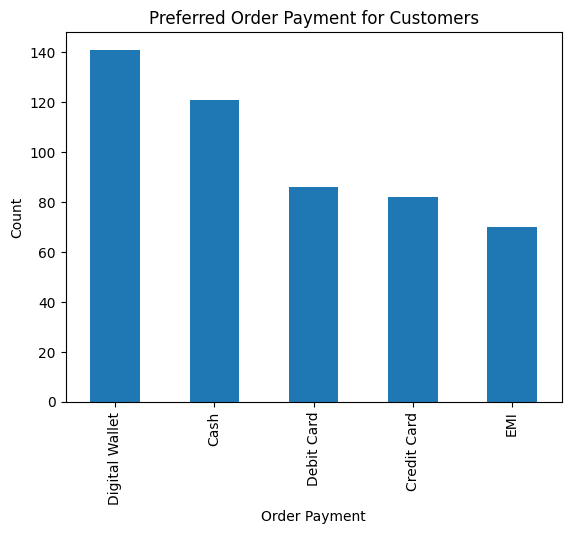

```
Preferred Order Payment: Digital Wallet
Percentage of Preferred Order Payment: 28.199999999999996
```

```python
# Group the data by order payment and calculate the count
order_payment_counts = dataset['order_payment'].value_counts()

# Plot the bar chart
order_payment_counts.plot(kind='bar')

# Set the labels and title
plt.xlabel('Order Payment')
plt.ylabel('Count')
plt.title('Preferred Order Payment for Customers')

# Display the plot
plt.show()

# Observations and Findings
preferred_order_payment = order_payment_counts.idxmax()
total_orders = dataset.shape[0]
percentage_preferred_payment = (order_payment_counts[preferred_order_payment] / total_orders) * 100

print("Preferred Order Payment:", preferred_order_payment)
print("Percentage of Preferred Order Payment:", percentage_preferred_payment)
```

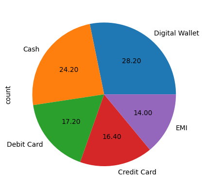

```python
# Plot the bar chart
dataset['order_payment'].value_counts().plot(kind='pie',autopct='%.2f')
```

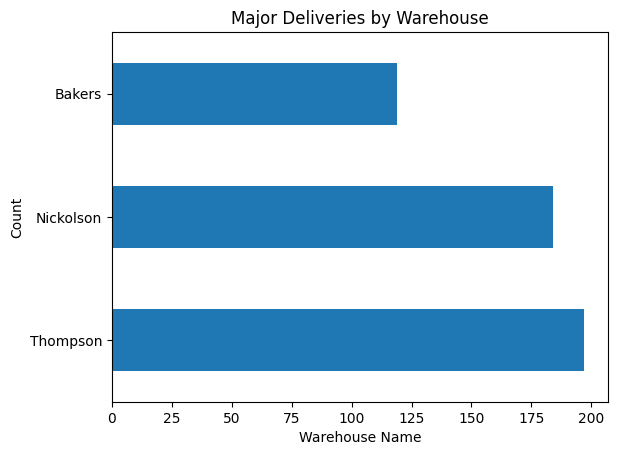

```
Major Deliveries from Warehouse: Thompson
Percentage of Major Deliveries from Warehouse: 39.4
```

```python
# Group the data by warehouse name and calculate the count
warehouse_counts = dataset['warehouse_name'].value_counts()

# Plot the bar chart
warehouse_counts.plot(kind='barh')

# Set the labels and title
plt.xlabel('Warehouse Name')
plt.ylabel('Count')
plt.title('Major Deliveries by Warehouse')

# Display the plot
plt.show()

# Observations and Findings
major_deliveries_warehouse = warehouse_counts.idxmax()
total_deliveries = dataset.shape[0]
percentage_major_deliveries = (warehouse_counts[major_deliveries_warehouse] / total_deliveries) * 100

print("Major Deliveries from Warehouse:", major_deliveries_warehouse)
print("Percentage of Major Deliveries from Warehouse:", percentage_major_deliveries)
```

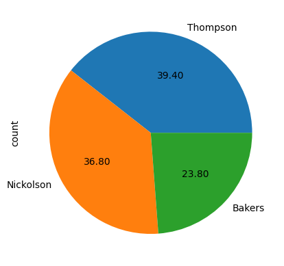

```python
# Plot the bar chart
dataset['warehouse_name'].value_counts().plot(kind='pie',autopct='%.2f')
```

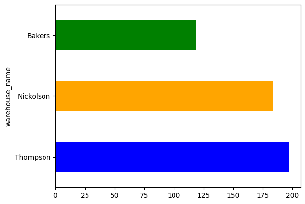

```python
dataset['warehouse_name'].value_counts().plot(kind='barh',color=['blue','orange', 'green']) # = matplotlib
```

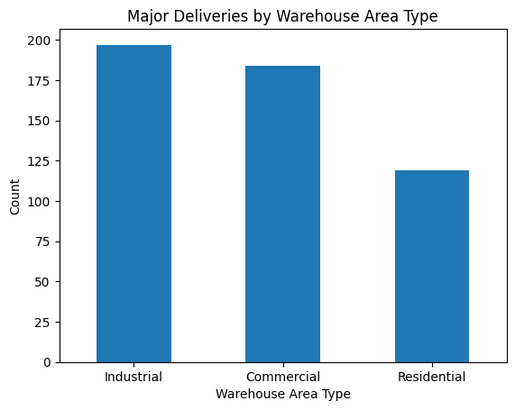

```
Major Deliveries from Warehouse Area Type: Industrial
Percentage of Major Deliveries from Warehouse Area Type: 39.4
```

```python
# Group the data by warehouse area type and calculate the count
warehouse_area_counts = dataset['warehouse_area_type'].value_counts()

# Plot the bar chart
warehouse_area_counts.plot(kind='bar')

# Set the labels and title
plt.xlabel('Warehouse Area Type')
plt.ylabel('Count')
plt.title('Major Deliveries by Warehouse Area Type')
plt.xticks(rotation=0)
# Display the plot
plt.show()

# Observations and Findings
major_deliveries_area = warehouse_area_counts.idxmax()
total_deliveries = dataset.shape[0]
percentage_major_deliveries = (warehouse_area_counts[major_deliveries_area] / total_deliveries) * 100

print("Major Deliveries from Warehouse Area Type:", major_deliveries_area)
print("Percentage of Major Deliveries from Warehouse Area Type:", percentage_major_deliveries)
```

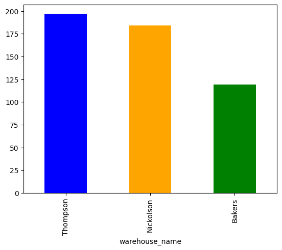

```python
dataset['warehouse_name'].value_counts().plot(kind='bar',color=['blue','orange', 'green']) # = matplotlib
```

```python
warehouse_area_counts
```

```
warehouse_area_type
Industrial     197
Commercial     184
Residential    119
Name: count, dtype: int64
```

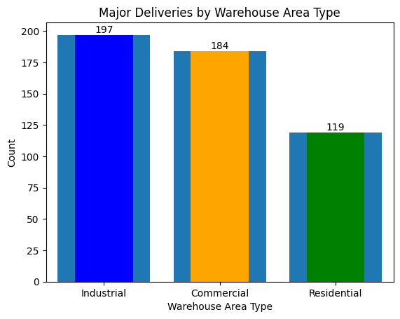

```
Major Deliveries from Warehouse Area Type: Industrial
Percentage of Major Deliveries from Warehouse Area Type: 39.4
```

```python
# Plot the bar chart
plt.bar(warehouse_area_counts.index, warehouse_area_counts.values)

# Plot the bar chart with customized colors
warehouse_area_counts.plot(kind='bar', color=['blue', 'orange', 'green'])

# Set the labels and title
plt.xlabel('Warehouse Area Type')
plt.ylabel('Count')
plt.title('Major Deliveries by Warehouse Area Type')

# Add data labels to the bar chart
for i, count in enumerate(warehouse_area_counts.values):
    plt.text(i, count, str(count), ha='center', va='bottom')

# Customize the appearance of the plot
plt.xticks(rotation=0)
#plt.grid(axis='y')

# Display the plot
plt.show()

# Observations and Findings
major_deliveries_area = warehouse_area_counts.idxmax()
total_deliveries = dataset.shape[0]
percentage_major_deliveries = (warehouse_area_counts[major_deliveries_area] / total_deliveries) * 100

print("Major Deliveries from Warehouse Area Type:", major_deliveries_area)
print("Percentage of Major Deliveries from Warehouse Area Type:", percentage_major_deliveries)
```

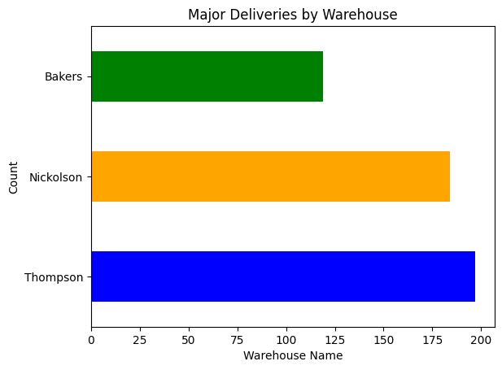

```
Major Deliveries from Warehouse: Thompson
Percentage of Major Deliveries from Warehouse: 39.4
```

```python
# Get the count of major deliveries by warehouse name
warehouse_counts = dataset['warehouse_name'].value_counts()

# Plot the bar chart with customized colors
warehouse_counts.plot(kind='barh', color=['blue', 'orange', 'green'])

# Set the labels and title
plt.xlabel('Warehouse Name')
plt.ylabel('Count')
plt.title('Major Deliveries by Warehouse')

# Rotate x-axis labels for horizontal display
plt.xticks(rotation=0)

# Display the plot
plt.show()

# Observations and Findings
major_deliveries_warehouse = warehouse_counts.idxmax()
total_deliveries = dataset.shape[0]
percentage_major_deliveries = (warehouse_counts[major_deliveries_warehouse] / total_deliveries) * 100

print("Major Deliveries from Warehouse:", major_deliveries_warehouse)
print("Percentage of Major Deliveries from Warehouse:", percentage_major_deliveries)
```

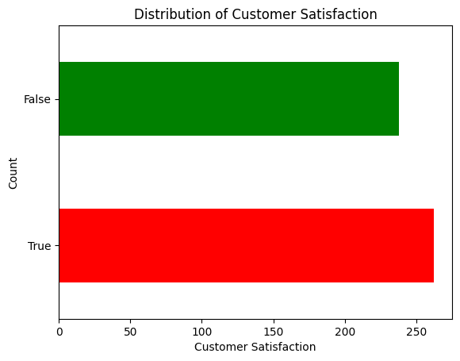

```
Most Common Customer Satisfaction Level: True
Percentage of Customers with the Most Common Satisfaction Level: 52.400000000000006
```

```python
# Group the data by customer satisfaction and calculate the count
satisfaction_counts = dataset['customer_satisfaction'].value_counts()

# Plot the bar chart
satisfaction_counts.plot(kind='barh', color=['red', 'green'])

# Set the labels and title
plt.xlabel('Customer Satisfaction')
plt.ylabel('Count')
plt.title('Distribution of Customer Satisfaction')
plt.xticks(rotation=0)

# Display the plot
plt.show()

# Observations and Findings
max_satisfaction = satisfaction_counts.idxmax()
total_customers = dataset.shape[0]
percentage_max_satisfaction = (satisfaction_counts[max_satisfaction] / total_customers) * 100

print("Most Common Customer Satisfaction Level:", max_satisfaction)
print("Percentage of Customers with the Most Common Satisfaction Level:", percentage_max_satisfaction)
```

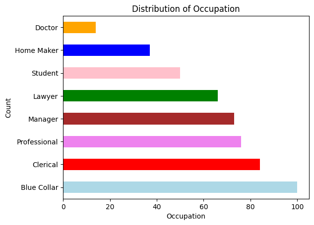

```
Most Common Occupation: Blue Collar
Percentage with the Most Common Occupation: 20.0
```

```python
# Group the data by customer occupation and calculate the count
occupation_counts = dataset['occupation'].value_counts()

# Plot the bar chart
occupation_counts.plot(kind='barh', color=['lightblue', 'red', 'violet', 'brown', 'green', 'pink', 'blue', 'orange', 'purple'])

# Set the labels and title
plt.xlabel('Occupation')
plt.ylabel('Count')
plt.title('Distribution of Occupation')
plt.xticks(rotation=0)
# Display the plot
plt.show()

# Observations and Findings
most_common_occupation = occupation_counts.idxmax()
total_customers = dataset.shape[0]
percentage_most_common_occupation = (occupation_counts[most_common_occupation] / total_customers) * 100

print("Most Common Occupation:", most_common_occupation)
print("Percentage with the Most Common Occupation:", percentage_most_common_occupation)
```

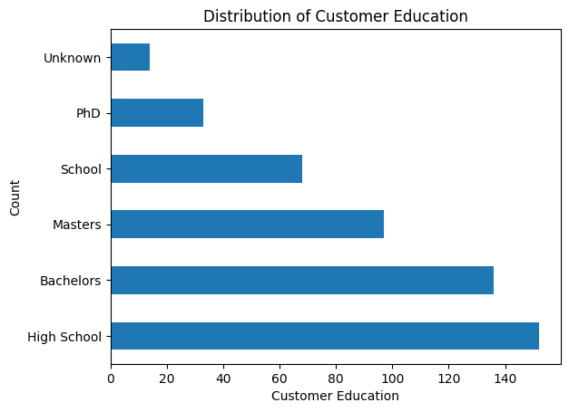

```
Most Common Customer Education: High School
Percentage of Customers with the Most Common Education: 30.4
```

```python
# Group the data by customer education and calculate the count
education_counts = dataset['education'].value_counts()

# Plot the bar chart
education_counts.plot(kind='barh')

# Set the labels and title
plt.xlabel('Customer Education')
plt.ylabel('Count')
plt.title('Distribution of Customer Education')

# Display the plot
plt.show()

# Observations and Findings
most_common_education = education_counts.idxmax()
total_customers = dataset.shape[0]
percentage_most_common_education = (education_counts[most_common_education] / total_customers) * 100

print("Most Common Customer Education:", most_common_education)
print("Percentage of Customers with the Most Common Education:", percentage_most_common_education)
```

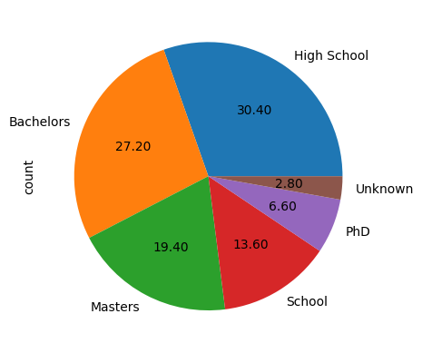

```python
# Plot the bar chart
dataset['education'].value_counts().plot(kind='pie',autopct='%.2f')
```

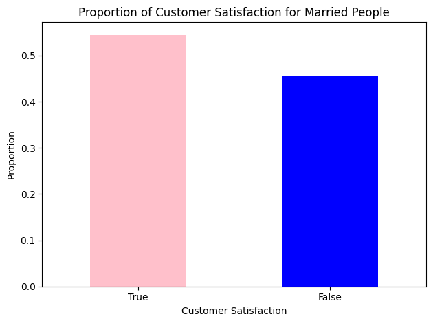

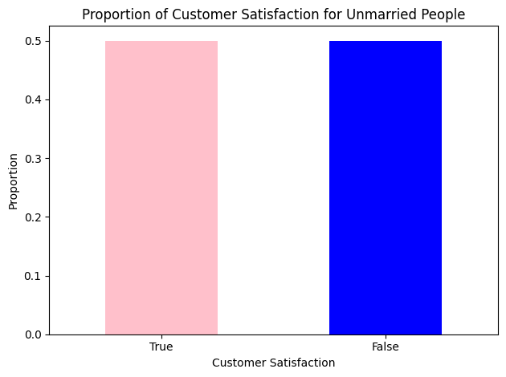

```
married_satisfaction_counts: customer_satisfaction
True     145
False    121
Name: count, dtype: int64
married_satisfaction_proportion_value: customer_satisfaction
True     0.545113
False    0.454887
Name: count, dtype: float64
Percentage of Customer Satisfaction for Married Customers: 54.51127819548872
unmarried_satisfaction_counts: customer_satisfaction
True     117
False    117
Name: count, dtype: int64
unmarried_satisfaction_proportion_value: customer_satisfaction
True     0.5
False    0.5
Name: count, dtype: float64
Percentage of Customer Satisfaction for Unmarried Customers: 50.0
```

```python
# Filter the data for married and unmarried customers
married_customers = dataset[dataset['marital_status'] == 'Yes']
unmarried_customers = dataset[dataset['marital_status'] == 'No']

# Calculate the proportion of customer satisfaction for married people
married_satisfaction_proportion = married_customers['customer_satisfaction'].value_counts(normalize=True)

# Calculate the proportion of customer satisfaction for unmarried people
unmarried_satisfaction_proportion = unmarried_customers['customer_satisfaction'].value_counts(normalize=True)

# Plot the stacked bar chart for married people
# plt.subplot(1, 2, 1)
married_satisfaction_proportion.plot(kind='bar', stacked=True, color=['pink', 'blue'])
plt.xlabel('Customer Satisfaction')
plt.ylabel('Proportion')
plt.title('Proportion of Customer Satisfaction for Married People')
plt.xticks(rotation=0)
# Adjust the layout and display the chart
plt.tight_layout()
plt.show()

# Plot the stacked bar chart for unmarried people
#plt.subplot(1, 2, 2)
unmarried_satisfaction_proportion.plot(kind='bar', stacked=True, color=['pink', 'blue'])
plt.xlabel('Customer Satisfaction')
plt.ylabel('Proportion')
plt.title('Proportion of Customer Satisfaction for Unmarried People')
plt.xticks(rotation=0)

# Adjust the layout and display the chart
plt.tight_layout()
plt.show()

# Calculate the proportion of customer satisfaction
married_satisfaction_counts = married_customers['customer_satisfaction'].value_counts()
married_satisfaction_proportion_value = married_satisfaction_counts / married_satisfaction_counts.sum()
print("married_satisfaction_counts:",married_satisfaction_counts)
print("married_satisfaction_proportion_value:",married_satisfaction_proportion_value)
print("Percentage of Customer Satisfaction for Married Customers:",(married_satisfaction_proportion_value[True]  * 100))

# Calculate the proportion of customer satisfaction
unmarried_satisfaction_counts = unmarried_customers['customer_satisfaction'].value_counts()
unmarried_satisfaction_proportion_value = unmarried_satisfaction_counts / unmarried_satisfaction_counts.sum()
print("unmarried_satisfaction_counts:",unmarried_satisfaction_counts)
print("unmarried_satisfaction_proportion_value:",unmarried_satisfaction_proportion_value)
print("Percentage of Customer Satisfaction for Unmarried Customers:",(unmarried_satisfaction_proportion_value[True] * 100))
```

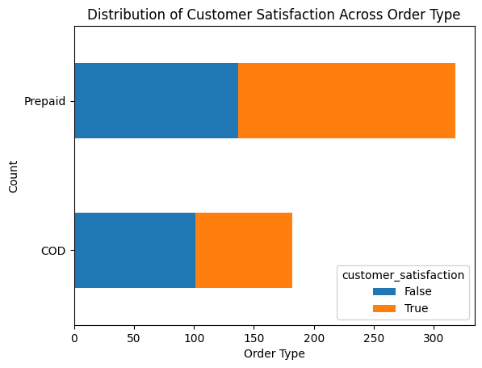

```python
# Group the data by order type and customer satisfaction, and count the occurrences
grouped = dataset.groupby(['order_type', 'customer_satisfaction']).size().unstack()

# Plot the stacked bar chart
grouped.plot(kind='barh', stacked=True)

# Set the labels and title
plt.xlabel('Order Type')
plt.ylabel('Count')
plt.title('Distribution of Customer Satisfaction Across Order Type')
plt.xticks(rotation=0)

# Display the plot
plt.show()
```

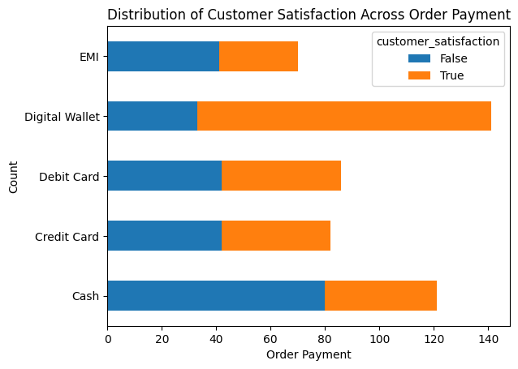

```python
# Group the data by order payment and customer satisfaction, and count the occurrences
grouped = dataset.groupby(['order_payment', 'customer_satisfaction']).size().unstack()

# Plot the stacked bar chart
grouped.plot(kind='barh', stacked=True)

# Set the labels and title
plt.xlabel('Order Payment')
plt.ylabel('Count')
plt.title('Distribution of Customer Satisfaction Across Order Payment')

# Display the plot
plt.show()
```

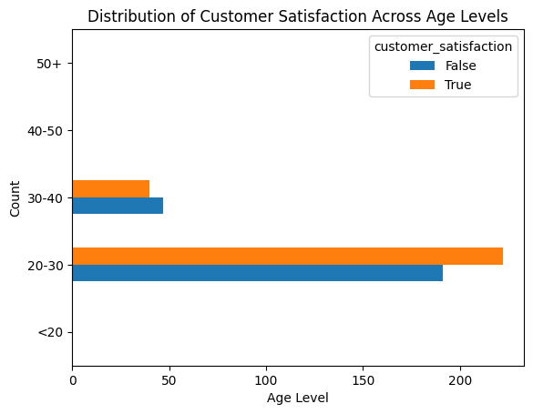

```python
# Define the age levels
age_bins = [0, 20, 30, 40, 50, float('inf')]
age_labels = ['<20', '20-30', '30-40', '40-50', '50+']

# Create a new column with age levels
dataset['age_level'] = pd.cut(dataset['age'], bins=age_bins, labels=age_labels)

# Group the data by age level and customer satisfaction, and count the occurrences
grouped = dataset.groupby(['age_level', 'customer_satisfaction']).size().unstack()

# Plot the stacked bar chart
grouped.plot(kind='barh', stacked=False)

# Set the labels and title
plt.xlabel('Age Level')
plt.ylabel('Count')
plt.title('Distribution of Customer Satisfaction Across Age Levels')

# Display the plot
plt.show()
```

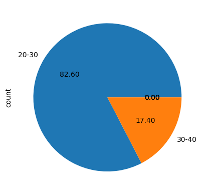

```python
# Plot the bar chart
dataset['age_level'].value_counts().plot(kind='pie',autopct='%.2f')
```

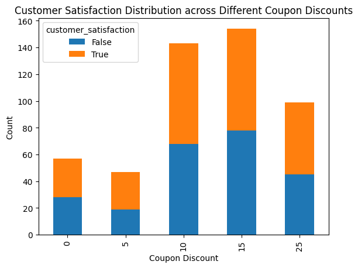

```python
# Group the data by coupon discount and customer satisfaction, and calculate the count
grouped = pd.crosstab(dataset['coupon_discount'], dataset['customer_satisfaction'])

# Plot the stacked bar chart
grouped.plot(kind='bar', stacked=True)

# Set the chart labels and title
plt.xlabel('Coupon Discount')
plt.ylabel('Count')
plt.title('Customer Satisfaction Distribution across Different Coupon Discounts')

# Display the chart
plt.show()
```

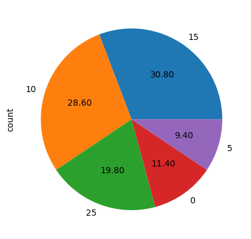

```python
# Plot the bar chart
dataset['coupon_discount'].value_counts().plot(kind='pie',autopct='%.2f')
```

```python
# Get the number of rows and columns in the dataset
num_rows, num_cols = dataset.shape
print('Number of rows:', num_rows)
print('Number of columns:', num_cols)

# Calculate the average order price
avg_order_price = dataset['order_price'].mean()
print('Average order price:', avg_order_price)

# Calculate the total delivery charges
total_delivery_charges = dataset['delivery_charges'].sum()
print('Total delivery charges:', total_delivery_charges)

# Calculate the maximum customer satisfaction
max_customer_satisfaction = dataset['customer_satisfaction'].max()
print('Maximum customer satisfaction:', max_customer_satisfaction)

# Count the number of expedited deliveries
num_expedited_deliveries = dataset['is_expedited_delivery'].sum()
print('Number of expedited deliveries:', num_expedited_deliveries)

# Calculate the total bill for all orders
total_bill = dataset['total_bill'].sum()
print('Total bill:', total_bill)
```

```
Number of rows: 500
Number of columns: 21
Average order price: 13794.323151999999
Total delivery charges: 38066.02
Maximum customer satisfaction: True
Number of expedited deliveries: 249
Total bill: 6044637.871679999
```

```python
!pip install pandas-profiling
```

[output not shown]

```python
import pandas as pd
import ydata_profiling

# Read the CSV file into a pandas DataFrame
df = pd.read_csv('technoecom.csv')

# Generate the profile report
profile = df.profile_report()

# Save the report as an HTML file
profile.to_file("profile_report.html")

# Save the report as an HTML file
profile.to_file("profile_report.docx")
```